# Ch. 16 HW due 3.13.22

## 5

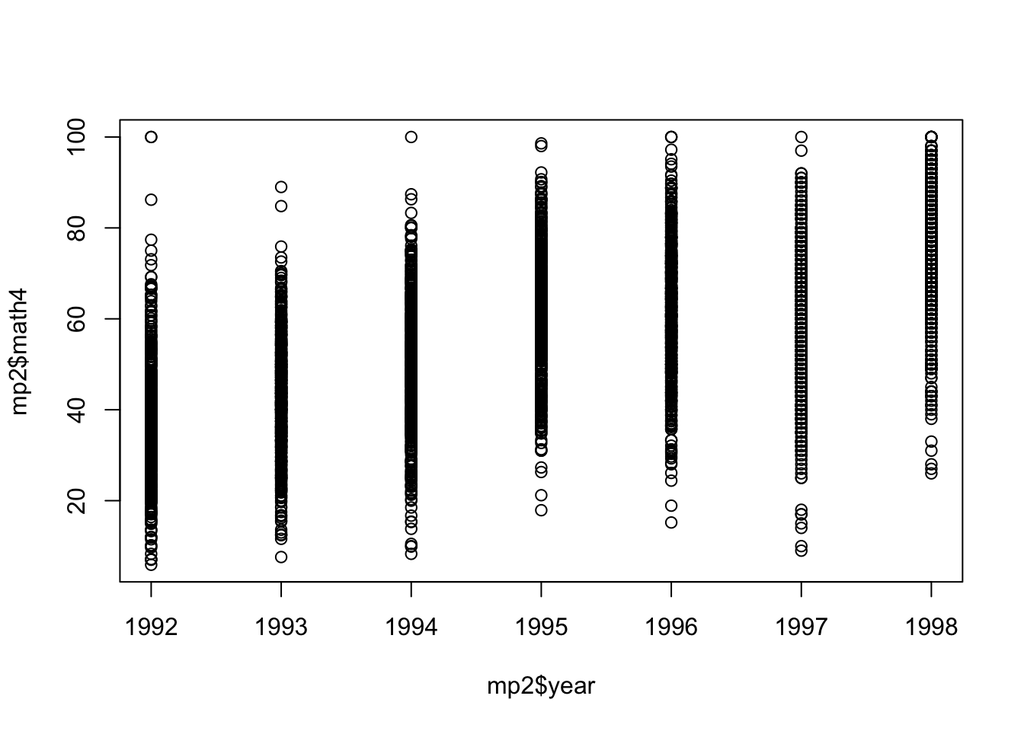

```r
plot(mp2$math4 ~ mp2$year) #checking for skew among variables to decide if some should be logged
```

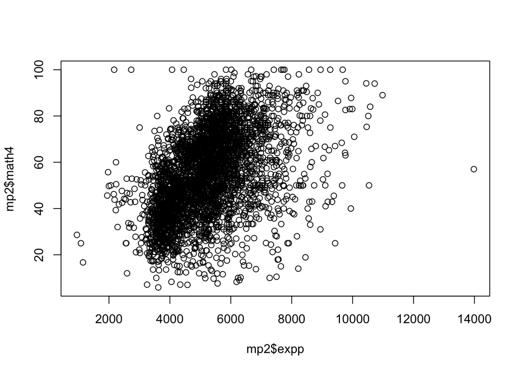

```r
plot(mp2$math4 ~ mp2$expp)
```

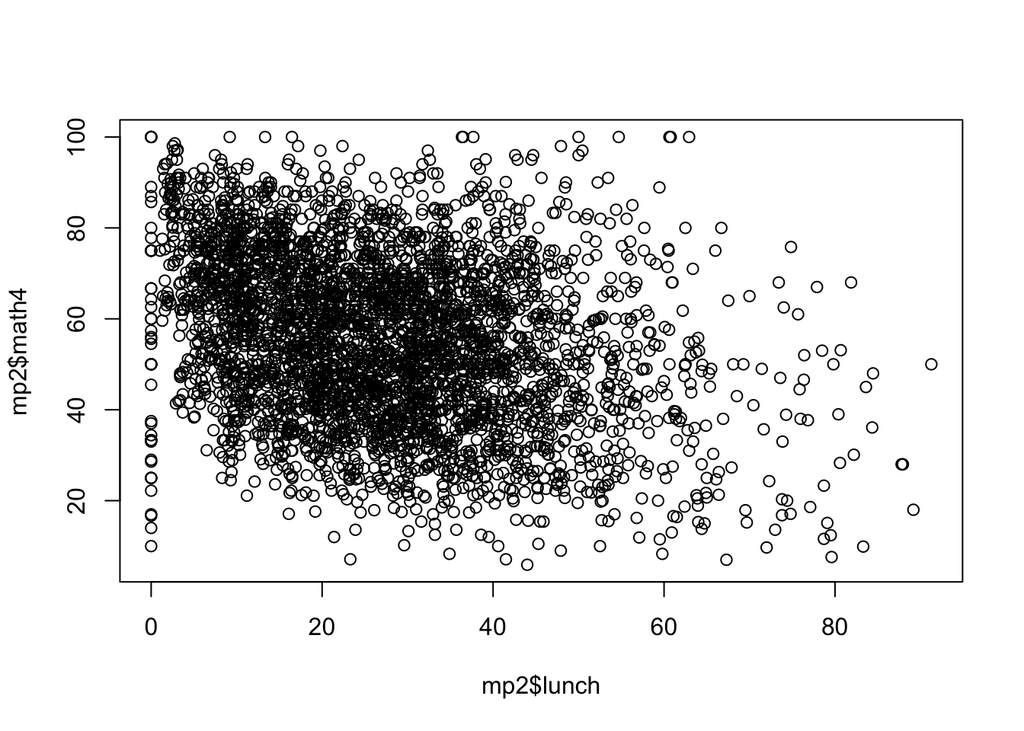

```r
plot(mp2$math4 ~ mp2$lunch) #noticed a couple of outliers for expp but otherwise looks ok
```

Subtract out the within-distid mean of math4, expp, and lunch, creating new variables math4_demean, expp_demean, and lunch_demean,

```r
mp2 <- mp2 |>
  group_by(distid) |> #performing calculation by distid
  mutate(math4_demean = math4 - mean(math4), #getting within variation by substracting mean
expp_demean = expp - mean(expp),
lunch_demean = lunch - mean(lunch)) |> ungroup()
```

re-estimate the model using those variables, storing the result as m2

```r
m2 <- lm(math4_demean ~ lunch_demean + expp_demean, data = mp2)
msummary(m2, stars = TRUE)
```

|  | Model 1 |
| --- | --- |
| (Intercept) | 0.000 |
|  | (0.166) |
| lunch_demean | 0.314*** |
|  | (0.050) |
| expp_demean | 0.012*** |
|  | (0.000) |
| Num.Obs. | 3850 |
| R2 | 0.499 |
| R2 Adj. | 0.499 |
| AIC | 28888.4 |
| BIC | 28913.4 |
| Log.Lik. | −14440.199 |
| F | 1915.184 |

+ p < 0.1, * p < 0.05, ** p < 0.01, *** p < 0.001

### Notice in m2 that the intercept is 0.

## 6

Run the model from step 4 but with dummies for different values of distid, saving the result as m3. Then, do a joint F test on the dummies, and report if you can reject that the dummies are jointly zero at the 99% level.Use only the first 500 observations of your data.

```r
mp3 <- mp2 |> top_n(500, distid) #selecting top 500 rows as ordered by distid and putting that in new set called mp3
mp3
```

```
## # A tibble: 504 × 8
##    distid  year math4  expp lunch math4_demean expp_demean lunch_demean
##     <dbl> <dbl> <dbl> <dbl> <dbl>        <dbl>       <dbl>        <dbl>
##  1  78070  1992  56.9  3865  6.60        -3.99       -965.       -3.44
##  2  78070  1993  50    4006  8.70       -10.9        -824.       -1.34
##  3  78070  1994  48.2  4535  8.80       -12.7        -295.       -1.24
##  4  78070  1995  55.1  5201 11.8         -5.79        371.        1.72
##  5  78070  1996  58    5489 11.4         -2.89        659.        1.31
##  6  78070  1997  70    5103 11.5          9.11        273.        1.47
##  7  78070  1998  88    5610 11.5         27.1         780.        1.50
##  8  78080  1992  27.4  3710 16.9        -22.2       -1318        -2.43
##  9  78080  1993  45.7  4288 19.6         -3.86       -740         0.266
## 10  78080  1994  43.4  4546 21.5         -6.16       -482         2.17
## # … with 494 more rows
```

```r
m3 <- lm(math4 ~ lunch + expp +  factor(distid), data = mp3) #using factor on distid to ensure that distid turns into a binary variable; running regression from step 4 that didn't have means
msummary(m3, stars = TRUE)
```

|  | Model 1 |
| --- | --- |
| (Intercept) | −4.086 |
|  | (4.497) |
| lunch | 0.451** |
|  | (0.151) |
| expp | 0.013*** |
|  | (0.001) |
| factor(distid)78080 | −18.005*** |
|  | (5.291) |
| factor(distid)78100 | −1.279 |
|  | (5.363) |
| factor(distid)78110 | −20.474*** |
|  | (5.723) |
| factor(distid)79010 | −15.780** |
|  | (6.003) |
| factor(distid)79020 | −17.669** |
|  | (5.942) |
| factor(distid)79030 | −4.518 |
|  | (5.813) |
| factor(distid)79080 | −30.143*** |
|  | (7.563) |
| factor(distid)79090 | −21.982*** |
|  | (5.974) |
| factor(distid)79100 | −21.648*** |
|  | (5.338) |
| factor(distid)79110 | −10.994+ |
|  | (5.794) |
| factor(distid)79145 | −16.810** |
|  | (5.762) |
| factor(distid)79150 | −23.421*** |
|  | (5.952) |

[output cut: 125 more lines]

+ p < 0.1, * p < 0.05, ** p < 0.01, *** p < 0.001

Doing joint F test using LinearHypothesis command in car package as instructed by chapter 13.

```r
library(car)
linearHypothesis(m3, matchCoefs(m3, "distid"), stars=TRUE)
```

```
## Linear hypothesis test
##
## Hypothesis:
## factor(distid)78080 = 0
## factor(distid)78100 = 0
## factor(distid)78110 = 0
## factor(distid)79010 = 0
## factor(distid)79020 = 0
## factor(distid)79030 = 0
## factor(distid)79080 = 0
## factor(distid)79090 = 0
## factor(distid)79100 = 0
## factor(distid)79110 = 0
## factor(distid)79145 = 0
## factor(distid)79150 = 0
## factor(distid)80000 = 0
## factor(distid)80010 = 0
## factor(distid)80020 = 0
## factor(distid)80050 = 0
## factor(distid)80090 = 0
## factor(distid)80110 = 0
## factor(distid)80120 = 0
## factor(distid)80130 = 0
## factor(distid)80140 = 0
## factor(distid)80150 = 0
## factor(distid)80160 = 0
## factor(distid)81000 = 0
## factor(distid)81010 = 0
## factor(distid)81020 = 0
## factor(distid)81040 = 0
## factor(distid)81050 = 0
## factor(distid)81070 = 0
## factor(distid)81080 = 0
## factor(distid)81100 = 0
## factor(distid)81120 = 0
## factor(distid)81140 = 0
## factor(distid)81150 = 0
## factor(distid)82010 = 0
## factor(distid)82020 = 0
## factor(distid)82030 = 0
```

[output cut: 28 more lines]

```
## factor(distid)82400 = 0
## factor(distid)82405 = 0
## factor(distid)82430 = 0
## factor(distid)83010 = 0
## factor(distid)83060 = 0
## factor(distid)83070 = 0
##
## Model 1: restricted model
## Model 2: math4 ~ lunch + expp + factor(distid)
##
##   Res.Df   RSS Df Sum of Sq      F    Pr(>F)
## 1    501 95823
## 2    430 39338 71     56485 8.6961 < 2.2e-16 ***
## ---
## Signif. codes:  0 '***' 0.001 '**' 0.01 '*' 0.05 '.' 0.1 ' ' 1
```

Reference: https://tyleransom.github.io/teaching/MetricsLabs/lab8.html

## 7

Use feols() to estimate the model from step 4 but with fixed effects for distid. Save the result as m4. Include standard errors clustered at the distid level.

```r
m4 <- feols(math4 ~ lunch + expp | distid, data = mp2)
m4.2 <- feols(math4 ~ lunch + expp | factor(distid), data = mp2) #ran a v2 of m4 to see if factor() makes a difference when using feols; it doesn't. The standard errors are clustered by distid and are clustered by the first fixed effect by default.
msummary(list(m4, m4.2), stars = TRUE)
```

|  | Model 1 | Model 2 |
| --- | --- | --- |
| lunch | 0.314*** | 0.314*** |
|  | (0.094) | (0.094) |
| expp | 0.012*** | 0.012*** |
|  | (0.000) | (0.000) |
| Num.Obs. | 3850 | 3850 |
| R2 | 0.680 | 0.680 |
| R2 Adj. | 0.626 | 0.626 |
| R2 Within | 0.499 | 0.499 |
| R2 Pseudo |  |  |
| AIC | 29984.4 | 29984.4 |
| BIC | 33437.6 | 33437.6 |
| Log.Lik. | −14440.199 | −14440.199 |
| Std.Errors | by: distid | by: factor(distid) |
| FE: distid | X |  |
| FE: factor(distid) |  | X |

+ p < 0.1, * p < 0.05, ** p < 0.01, *** p < 0.001

### Interpretation: Given its district, and adjusting for expp, in a year when lunch is one unit higher than average we would expect math4 to be 0.314 units higher than average for that district.

## 8

Now add fixed effects for year to your model from step 7 to create a two-way fixed effects model. Keep the standard errors clustered at the distid level. Save the results as m5.

```r
m5 <- feols(math4 ~ lunch + expp | distid + year, data = mp2)
msummary((m5), stars = TRUE)
```

|  | Model 1 |
| --- | --- |
| lunch | 0.018 |
|  | (0.100) |
| expp | 0.000 |
|  | (0.001) |
| Num.Obs. | 3850 |
| R2 | 0.793 |
| R2 Adj. | 0.758 |
| R2 Within | 0.000 |
| R2 Pseudo |  |
| AIC | 28319.5 |
| BIC | 31810.3 |
| Log.Lik. | −13601.767 |
| Std.Errors | by: distid |
| FE: distid | X |
| FE: year | X |

+ p < 0.1, * p < 0.05, ** p < 0.01, *** p < 0.001

## 9

Using modelsummary() from **modelsummary** make a regression table including m1 through m5 in the same table so you can compare them all. Read the documentation of your command to figure out how to include the expp, lunch, expp_demean, and lunch_demean predictors in the table without clogging the thing up with a bunch of dummy coefficients from m3.

```r
models <- list(m1, m2, m3, m4, m5)

modelsummary(models, coef_omit = "factor") #hiding dummies for distid
```

|  | Model 1 | Model 2 | Model 3 | Model 4 | Model 5 |
| --- | --- | --- | --- | --- | --- |
| (Intercept) | 29.527 | 0.000 | −4.086 |  |  |
|  | (1.139) | (0.166) | (4.497) |  |  |
| expp | 0.007 |  | 0.013 | 0.012 | 0.000 |
|  | (0.000) |  | (0.001) | (0.000) | (0.001) |
| lunch | −0.381 |  | 0.451 | 0.314 | 0.018 |
|  | (0.016) |  | (0.151) | (0.094) | (0.100) |
| lunch_demean |  | 0.314 |  |  |  |
|  |  | (0.050) |  |  |  |
| expp_demean |  | 0.012 |  |  |  |
|  |  | (0.000) |  |  |  |
| Num.Obs. | 3850 | 3850 | 504 | 3850 | 3850 |
| R2 | 0.308 | 0.499 | 0.755 | 0.680 | 0.793 |
| R2 Adj. | 0.307 | 0.499 | 0.713 | 0.626 | 0.758 |
| R2 Within |  |  |  | 0.499 | 0.000 |
| R2 Pseudo |  |  |  |  |  |
| AIC | 31856.6 | 28888.4 | 3776.4 | 29984.4 | 28319.5 |
| BIC | 31881.6 | 28913.4 | 4093.1 | 33437.6 | 31810.3 |
| Log.Lik. | −15924.294 | −14440.199 | −1813.205 | −14440.199 | −13601.767 |
| F | 855.419 | 1915.184 | 18.150 |  |  |
| Std.Errors |  |  |  | by: distid | by: distid |
| FE: distid |  |  |  | X | X |
| FE: year |  |  |  |  | X |

Write down two interesting things you notice from the table:

### Two interesting things on this table are that 1) the coefficient for lunch was negative in the first model without fixed effects and positive in the subsequent models and 2) the coefficient for expp increased between model 1 to model 2, but then decreased. It would be helpful to discuss in class how to interpret such changes in the size of coefficients across models.

## 10

You already have expp_demean and lunch_demean from earlier. Now, modify the code from that slightly to add on expp_mean and lunch_mean (the mean within distid instead of the value minus that mean). Then, regress math4 on expp_demean, lunch_demean, expp_mean, and lunch_mean, with random effects for distid using lmer() from lme4. Show a summary of the regression results.

```r
mp2 <- mp2 |>
  group_by(distid) |> #performing calculation by distid
  mutate(expp_mean = mean(expp),
lunch_mean = mean(lunch)) |> ungroup()
```

```r
library(lme4)
m6 <- lmer(math4 ~ expp_demean + lunch_demean + expp_mean + lunch_mean | distid, data = mp2)
msummary(m6, stars = TRUE)
```

|  | Model 1 |
| --- | --- |
| (Intercept) | 55.069*** |
|  | (3.370) |
| SD (Intercept) | 9.353 |
| SD (expp_demean) | 0.015 |
| SD (lunch_demean) | 0.461 |
| SD (expp_mean) | 0.001 |
| SD (lunch_mean) | 8.812 |
| Cor (Intercept~expp_demean) | 0.702 |
| Cor (Intercept~lunch_demean) | 0.001 |
| Cor (Intercept~expp_mean) | 0.465 |
| Cor (Intercept~lunch_mean) | 0.008 |
| SD (Observations) | 9.266 |
| Num.Obs. | 3850 |
| RMSE | 8.55 |

+ p < 0.1, * p < 0.05, ** p < 0.01, *** p < 0.001

After doing this correlated random effects process, I don’t know how to interpret the above table. Should we think of some of this as interactions?